# markov_order_test(): does memory exist at all?

honets

2026-08-26

## The analytic question

Every higher-order method in this package assumes the sequences have memory. `markov_order_test()` is the question you should ask **before** any of them: does the past predict the future beyond the present state, and if so, how far back?

It fits Markov chains of increasing order, compares them by likelihood-ratio, and — because the asymptotic chi-square reference is unreliable when the transition table is sparse — calibrates the statistic against a **permutation null** built by shuffling within sequences.

```r
library(honets)
seqs <- split(human_long$code, human_long$session_id)
wide <- as.data.frame(do.call(rbind, lapply(
  seqs, function(s) c(s, rep(NA, max(lengths(seqs)) - length(s))))),
  stringsAsFactors = FALSE)
```

## Running it

```r
mk <- markov_order_test(wide, max_order = 3, n_perm = 200, seed = 1)
mk
```

```
Markov Order Test  [within-w permutation, n_perm = 200, alpha = 0.050]
  425 sequences / 10792 observations / 9 states

  Selected order  BIC: 1   AIC: 3   permutation-LRT: 3

 order    loglik      AIC      BIC   df      g2 p_permutation  p_asymptotic
     0 -22031.34 44078.69 44136.98   NA      NA            NA            NA
     1 -20829.39 41818.79 42401.71   64 2375.35   0.004975124  0.000000e+00
     2 -19841.13 41084.25 46192.13  576 1823.84   0.004975124 1.707029e-129
     3 -17163.27 40684.54 63848.51 4721 5191.45   0.004975124  1.324824e-06
 significant
          NA
        TRUE
        TRUE
        TRUE
```

Three criteria, and they **disagree**: BIC selects order 1, AIC and the permutation LRT both select order 3. That disagreement is the result, not a problem to resolve away.

```r
as.data.frame(mk)
```

```
  order    loglik      AIC      BIC   df       g2 p_permutation  p_asymptotic
1     0 -22031.34 44078.69 44136.98   NA       NA            NA            NA
2     1 -20829.39 41818.79 42401.71   64 2375.354   0.004975124  0.000000e+00
3     2 -19841.13 41084.25 46192.13  576 1823.837   0.004975124 1.707029e-129
4     3 -17163.27 40684.54 63848.51 4721 5191.451   0.004975124  1.324824e-06
  significant
1          NA
2        TRUE
3        TRUE
4        TRUE
```

## Reading the disagreement

Look at the `df` column. Going from order 2 to order 3 costs **4,721 extra parameters** on 10,792 observations. AIC charges 2 per parameter; BIC charges `log(n)` ≈ 9.3. On data this size the two criteria are answering different questions:

- **AIC** asks which order predicts best out of sample. It says 3.
- **BIC** asks which order is most likely to be the true generating model. It says 1, because the parameter cost of a third-order chain is enormous relative to the evidence.

Both are right about their own question. For *description* — which is what `build_hon()` does — the AIC/LRT answer is the relevant one, and it is why `max_order = 3` is a sensible ceiling for these data. For a claim that the process **is** third-order Markov, BIC’s scepticism should be reported.

## Seeing the test

`plot()` puts the two panels side by side: the information criteria by order, and the observed statistic against its permutation null. The second panel is the one to read — it shows *how far* outside the null the observed value sits, which the p-value’s floor cannot express.

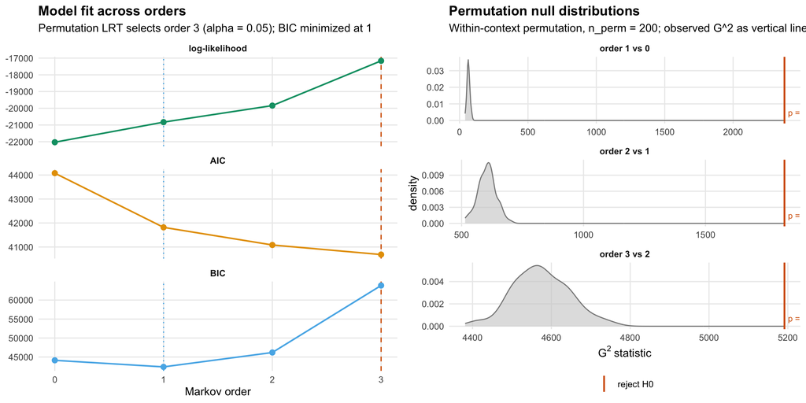

```r
plot(mk)
```

## The permutation p-value has a floor

```r
as.data.frame(mk)
```

```
  order    loglik      AIC      BIC   df       g2 p_permutation  p_asymptotic
1     0 -22031.34 44078.69 44136.98   NA       NA            NA            NA
2     1 -20829.39 41818.79 42401.71   64 2375.354   0.004975124  0.000000e+00
3     2 -19841.13 41084.25 46192.13  576 1823.837   0.004975124 1.707029e-129
4     3 -17163.27 40684.54 63848.51 4721 5191.451   0.004975124  1.324824e-06
  significant
1          NA
2        TRUE
3        TRUE
4        TRUE
```

Every permutation p-value is 0.004975 — that is `1 / (200 + 1)`, the **smallest value 200 permutations can produce**. It does not mean the three orders are equally significant; it means all three exceeded every one of their 200 null replicates. Raise `n_perm` if you need to resolve below that floor.

Note also how far the asymptotic p-values sit from it: 1.7e-129 at order 2. That is the sparsity problem the permutation null exists to avoid — with 576 degrees of freedom over nine states, the chi-square approximation is not trustworthy, and the permutation value is the one to report.

## The null distribution itself

`what = "null"` returns the replicates, so the calibration can be inspected rather than trusted.

```r
nulls <- as.data.frame(mk, what = "null")
as.data.frame(mk, what = "null", top = 4)
```

```
  order replicate       g2
1     1         1 67.28721
2     1         2 83.43090
3     1         3 67.25021
4     1         4 72.83490
```

```r
aggregate(g2 ~ order, data = nulls,
          FUN = function(x) round(c(mean = mean(x), max = max(x)), 1))
```

```
  order g2.mean g2.max
1     1    65.1   98.7
2     2   604.4  706.7
3     3  4574.3 4766.5
```

Compare each order’s observed `g2` in the table above against the maximum its null ever reached. The observed statistics are far outside — which is what “p at the floor” means, made concrete.

## Cost and reproducibility

Permutations dominate the runtime. `parallel = TRUE` uses `parallel::mclapply` (skipped on Windows), and all randomness is drawn serially before any parallel work, so **a parallel run reproduces the serial result exactly under the same seed**.

```r
markov_order_test(wide, max_order = 3, n_perm = 2000,
                  parallel = TRUE, n_cores = 4, seed = 1)
```

Always pass `seed`. A permutation test reported without one is not reproducible.

## What to do next

- **`build_hon()`** — if there is memory, build the network that represents it. Use the selected order as the `max_order` ceiling.
- **`path_dependence()`** — this test is global. That one localises the memory to individual contexts.
- **`build_mogen()`** — the same model-selection question under a multi-order generative model, which mixes orders rather than choosing one.

## References

- Anderson, T. W., & Goodman, L. A. (1957). Statistical inference about Markov chains. *The Annals of Mathematical Statistics*, 28(1), 89-110.
- Good, P. (2005). *Permutation, Parametric and Bootstrap Tests of Hypotheses*. Springer.